# State MSM Profile: **Maryland**

### Background & Methods

In 2015-2016, researchers at Emory University partnered with colleagues at the Centers for Disease Control and Prevention (CDC) to develop methods to estimate the number of men who have sex with men (MSM) residing in each county in the United States. Using population and housing data from the [American Community Survey](https://www.census.gov/programs-surveys/acs/) and estimates from two peer-reviewed publications ([Oster et al., 2015](http://www.ncbi.nlm.nih.gov/pubmed/26115985) & [Purcell et al., 2012](http://www.ncbi.nlm.nih.gov/pubmed/23049658)), they derived an indirect estimate of MSM population sizes that took into account both the urbanicity of the county as well as its density of households with a male householder and a male same-sex partner.

The full methodology is published in the *Journal of Medical Internet Research - Public Health and Surveillance*:

> [Grey JA, Bernstein KT, Sullivan PS, Purcell DW, Chesson HW, Gift TL, Rosenberg ES. Estimating the population sizes of men who have sex with men in US states and counties using data from the American Community Survey. JMIR Public Health Surveill 2016;2(1):e14. DOI: 10.2196/publichealth.5365](http://publichealth.jmir.org/2016/1/e14/)

### Overview of MSM in Maryland

An estimated **84,465** men who have sex with men (MSM) resided in Maryland in 2013, representing 1.9% of the 4,503,084 MSM in the United States. Of the 2,136,890 adult men of Maryland, 4.0% had had sex with another man in the past 5 years, which was greater than the overall percentage of adult men in the United States who were MSM (3.9%).

Most MSM in Maryland resided in fringe counties of large metropolitan areas (74.9%). Including both central and fringe counties, 93.9% resided in a large metropolitan area.

##### **Percentage of MSM by urbanicity, United States and Maryland, 2013**

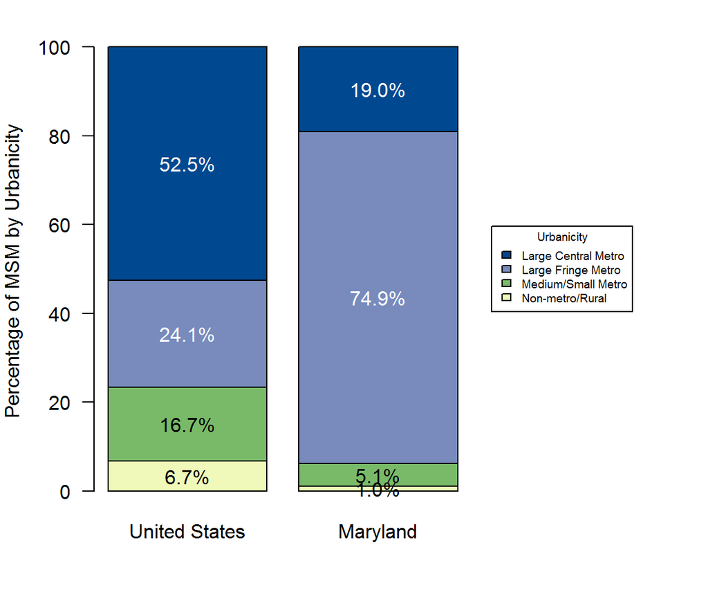

### MSM in Maryland Counties

Among counties or county-equivalent areas in Maryland, Baltimore city had the largest population of MSM at 16,050, representing 19.0% of all MSM in the state. Baltimore city also had the highest percentage of MSM among adult men in Maryland at 7.1%. This was greater than the percentage for Maryland as a whole, which was 4.0% of adult men.

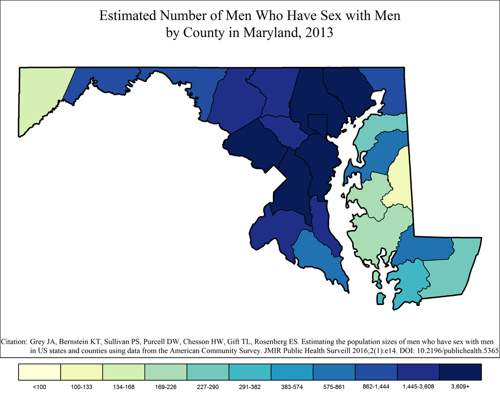

Note: Range cutpoints for the map are based on the distribution of MSM among all counties in the United States.

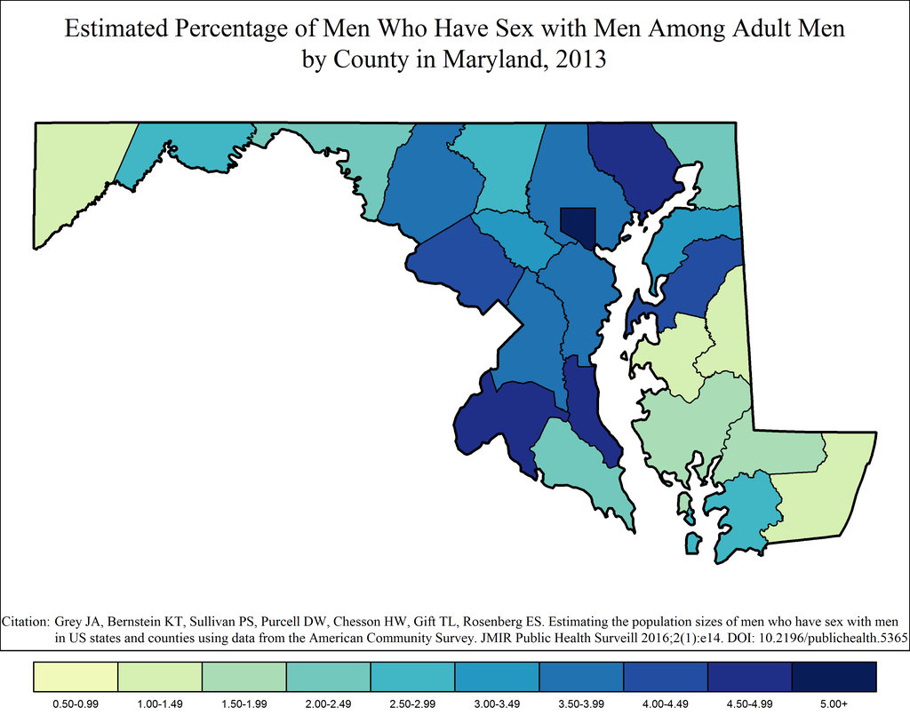

### MSM in Maryland Metropolitan Statistical Areas

#### Baltimore-Columbia-Towson Metropolitan Statistical Area

The Baltimore-Columbia-Towson MSA had the largest metropolitan population of MSM in Maryland at 45,175, or 53.5% of all MSM in the state. Of the 1,001,125 adult men in Baltimore-Columbia-Towson, an estimated 4.5% were MSM.

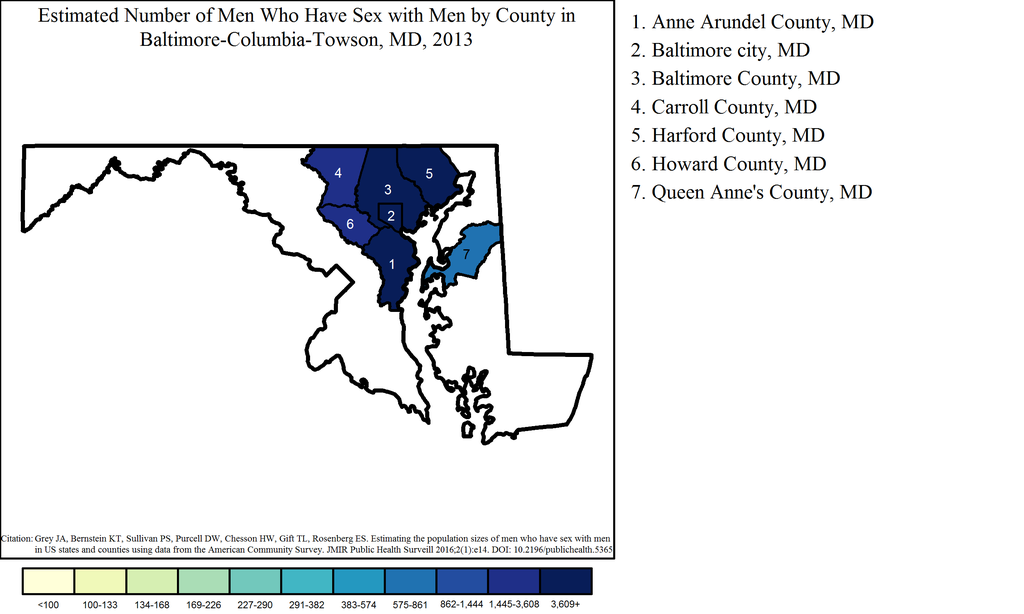

Note: Range cutpoints for the map are based on the distribution of MSM among all counties in the United States.

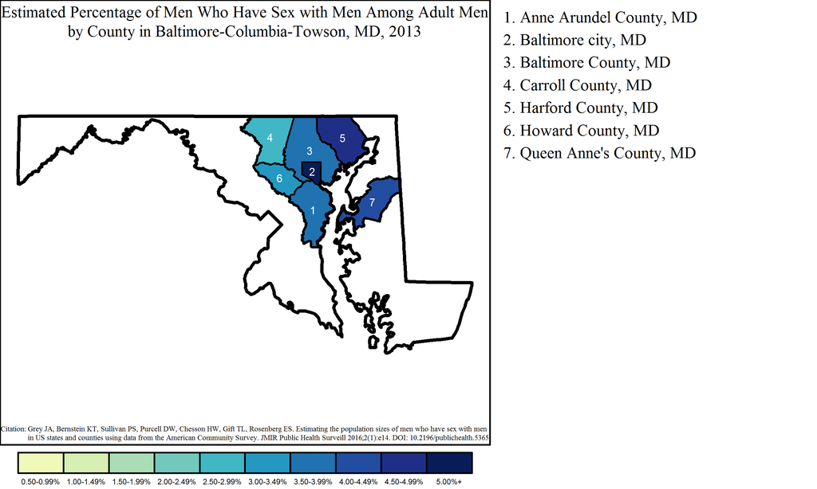

#### Washington-Arlington-Alexandria Metropolitan Statistical Area

The Washington-Arlington-Alexandria MSA overlaps three states – Maryland, Virginia and West Virginia – and the District of Columbia. The Maryland portion of the MSA had 33,184 MSM, or 39.3% of all MSM in the state and 27.0% of the 122,895 MSM in the MSA. Of 842,189 adult men in the Maryland part of Washington-Arlington-Alexandria, 3.9% were MSM. This was less than the overall percentage of MSM among adult men in the MSA, which was 5.8% of adult men (122,895 out of 2,113,258).

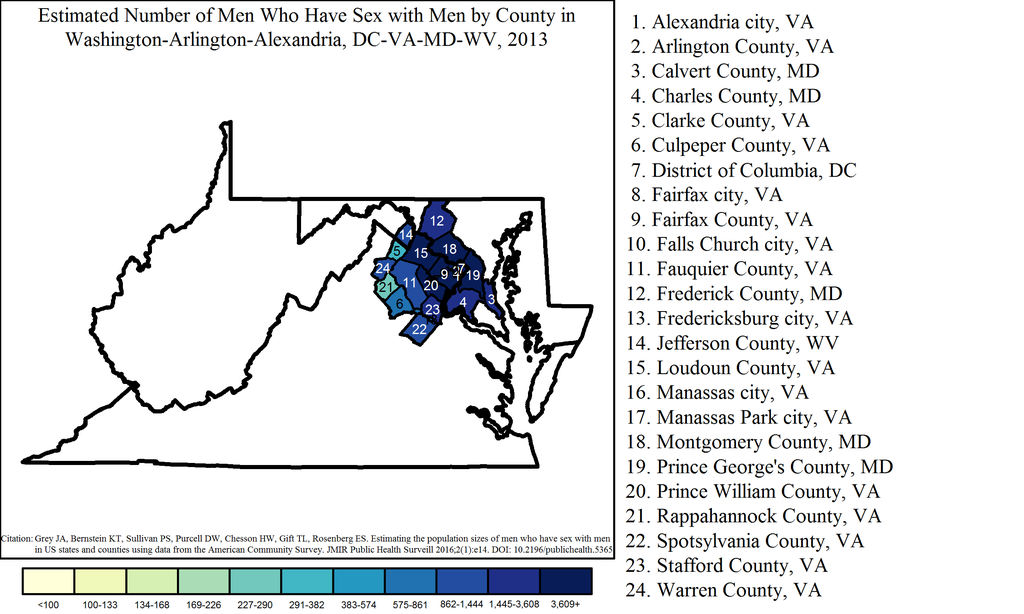

Note: Range cutpoints for the map are based on the distribution of MSM among all counties in the United States.

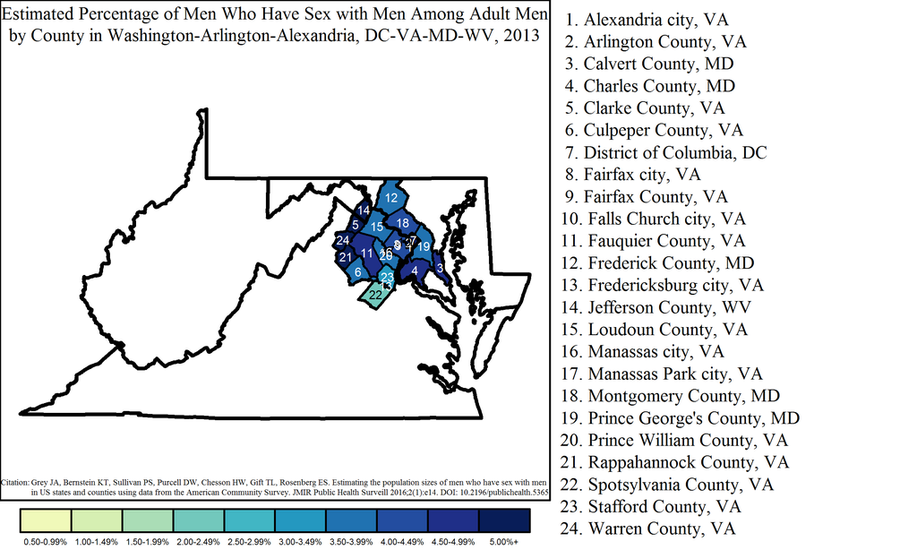

#### Hagerstown-Martinsburg Metropolitan Statistical Area

The Hagerstown-Martinsburg MSA overlaps two states: Maryland and West Virginia. The Maryland portion of the MSA had 1,348 MSM, or 1.6% of all MSM in the state and 58.6% of the 2,299 MSM in the MSA. Of 58,413 adult men in the Maryland part of Hagerstown-Martinsburg, 2.3% were MSM. This was less than the overall percentage of MSM among adult men in the MSA, which was 2.4% of adult men (2,299 out of 97,379).

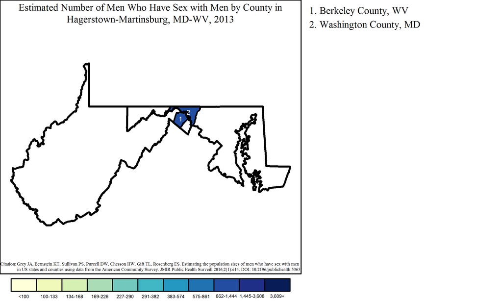

Note: Range cutpoints for the map are based on the distribution of MSM among all counties in the United States.

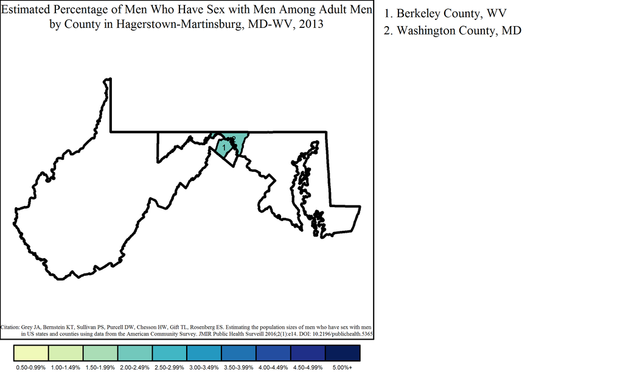

#### Salisbury Metropolitan Statistical Area

The Salisbury MSA overlaps two states: Delaware and Maryland. The Maryland portion of the MSA had 1,227 MSM, or 1.5% of all MSM in the state and 22.9% of the 5,365 MSM in the MSA. Of 68,731 adult men in the Maryland part of Salisbury, 1.8% were MSM. This was less than the overall percentage of MSM among adult men in the MSA, which was 3.7% of adult men (5,365 out of 145,918).

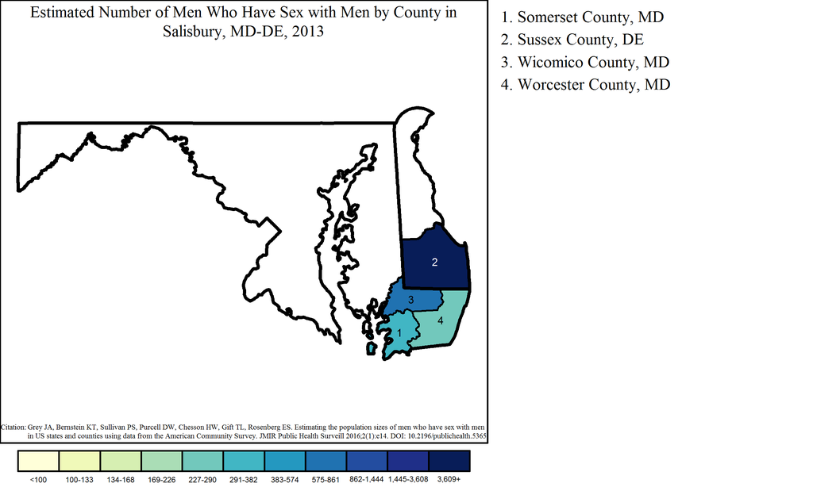

Note: Range cutpoints for the map are based on the distribution of MSM among all counties in the United States.

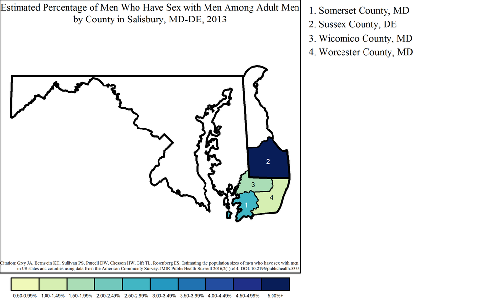

#### Philadelphia-Camden-Wilmington Metropolitan Statistical Area

The Philadelphia-Camden-Wilmington MSA overlaps four states: Delaware, Maryland, New Jersey and Pennsylvania. The Maryland portion of the MSA had 920 MSM, or 1.1% of all MSM in the state and 0.9% of the 100,293 MSM in the MSA. Of 37,643 adult men in the Maryland part of Philadelphia-Camden-Wilmington, 2.4% were MSM. This was less than the overall percentage of MSM among adult men in the MSA, which was 4.6% of adult men (100,293 out of 2,189,761).

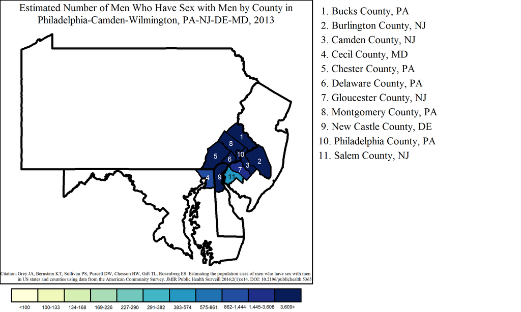

Note: Range cutpoints for the map are based on the distribution of MSM among all counties in the United States.

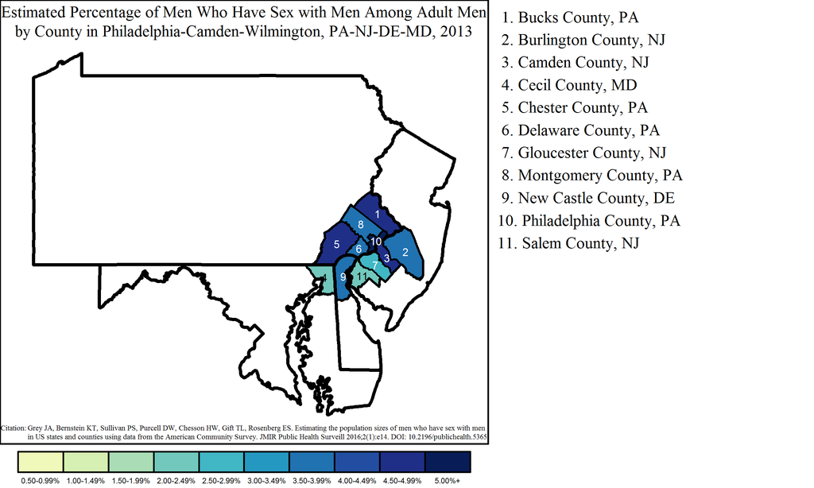

#### Cumberland Metropolitan Statistical Area

The Cumberland MSA overlaps two states: Maryland and West Virginia. The Maryland portion of the MSA had 898 MSM, or 1.1% of all MSM in the state and 88.6% of the 1,014 MSM in the MSA. Of 31,693 adult men in the Maryland part of Cumberland, 2.8% were MSM. This was greater than the overall percentage of MSM among adult men in the MSA, which was 2.4% of adult men (1,014 out of 42,491).

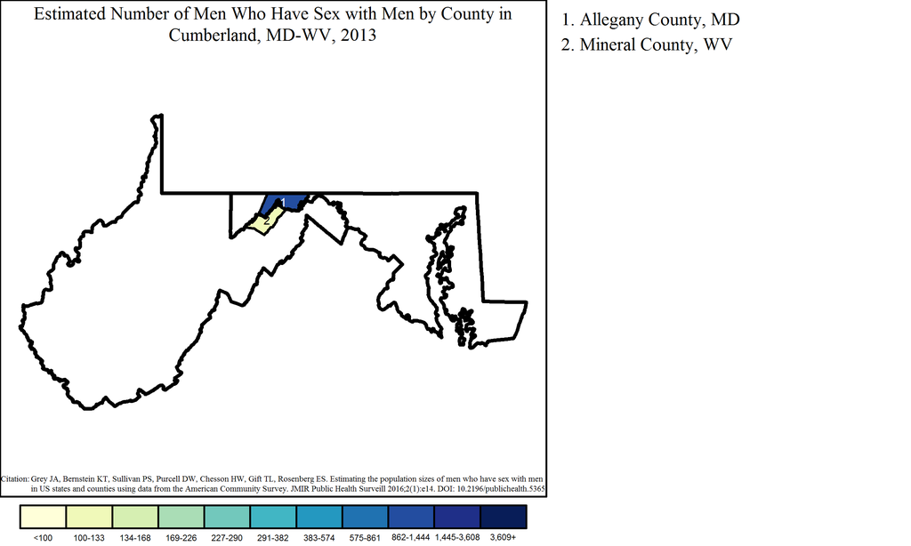

Note: Range cutpoints for the map are based on the distribution of MSM among all counties in the United States.

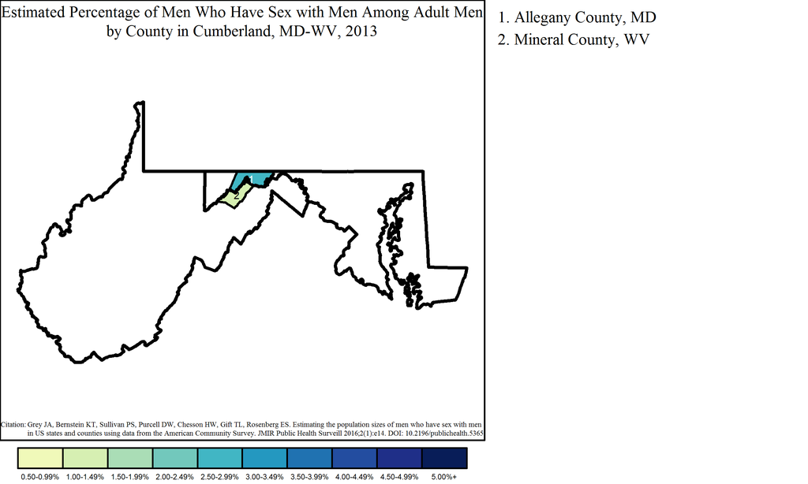

#### California-Lexington Park Metropolitan Statistical Area

The California-Lexington Park MSA had a population of 834 MSM, or 1.0% of all MSM in Maryland. Of the 39,413 adult men in California-Lexington Park, an estimated 2.1% were MSM.

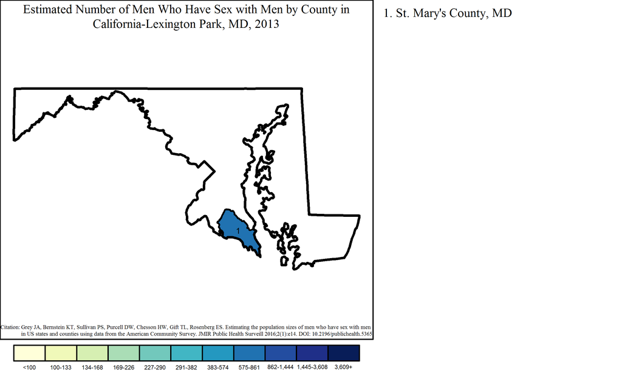

Note: Range cutpoints for the map are based on the distribution of MSM among all counties in the United States.

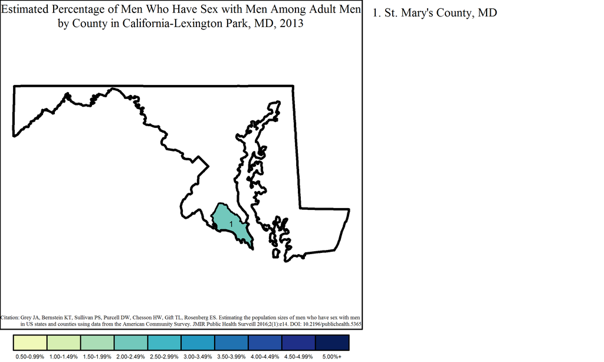